# Unit 04-MSDS Doing Data Science

Eduardo Cantu Medellin

February 2, 2018

## FiveThirtyEight Data

Navigate on GitHub to https://github.com/rudeboybert/fivethirtyeight and read README.md. Seriously, it will include everything you need. • Install the fivethirtyeight package.  
• In the listing of Data sets in package ‘fivethirtyeight,’ assign the eighteenth data set to an object ‘df.’  
• Use a more detailed list of the data sets to write out the URL in a comment to the related news story.  
• Using R command(s), give the dimensions and column names of this data frame.

```r
#Loads the "fivethirtyeight" library
library(fivethirtyeight)

#Lists all the data sets for "fivethirtyeight"
data(package="fivethirtyeight")

#Load the eighteenth data set from the fivethirtyeight : "college_recent_grads"
df <- college_recent_grads

#A more detailed list of the datasets
vignette("fivethirtyeight", package = "fivethirtyeight")
```

```
## starting httpd help server ... done
```

```r
#Dimensions and column names for df
dim(df) # Row Columns
```

```
## [1] 173  21
```

```r
names(df) # Column Names for the data frame
```

```
##  [1] "rank"                        "major_code"
##  [3] "major"                       "major_category"
##  [5] "total"                       "sample_size"
##  [7] "men"                         "women"
##  [9] "sharewomen"                  "employed"
## [11] "employed_fulltime"           "employed_parttime"
## [13] "employed_fulltime_yearround" "unemployed"
## [15] "unemployment_rate"           "p25th"
## [17] "median"                      "p75th"
## [19] "college_jobs"                "non_college_jobs"
## [21] "low_wage_jobs"
```

## Data Summary

• Write an R command that gives you the column names of the data frame. Right after that, write one that counts the number of columns but not rows. Hint: The number should match one of your numbers in Question 1d for dimensions.  
• Generate a count of each unique major_category in the data frame. I recommend using libraries to help. I have demonstrated one briefly in live-session. To be clear, this should look like a matrix or data frame containing the major_category and the frequency it occurs in the dataset. Assign it to major_count.  
• To make things easier to read, put par(las=2) before your plot to make the text perpendicular to the axis. Make a barplot of major_count. Make sure to label the title with something informative (check the vignette if you need), label the x and y axis, and make it any color other than grey. Assign the major_category labels to their respective bar. Flip the barplot horizontally so that bars extend to the right, not upward. All of these options can be done in a single pass of barplot(). Note: It’s okay if it’s wider than the preview pane.  
• Write the fivethirtyeight data to a csv file. Make sure that it does not have row labels.

```r
#Column Names and Column Count for data frame
names(df)  # Column Na
```

```
##  [1] "rank"                        "major_code"
##  [3] "major"                       "major_category"
##  [5] "total"                       "sample_size"
##  [7] "men"                         "women"
##  [9] "sharewomen"                  "employed"
## [11] "employed_fulltime"           "employed_parttime"
## [13] "employed_fulltime_yearround" "unemployed"
## [15] "unemployment_rate"           "p25th"
## [17] "median"                      "p75th"
## [19] "college_jobs"                "non_college_jobs"
## [21] "low_wage_jobs"
```

```r
ncol(df)  # Column Count
```

```
## [1] 21
```

```r
# Summary
major_count <- table(df$major_category)

as.data.frame(major_count)
```

```
##                                   Var1 Freq
## 1      Agriculture & Natural Resources   10
## 2                                 Arts    8
## 3               Biology & Life Science   14
## 4                             Business   13
## 5          Communications & Journalism    4
## 6              Computers & Mathematics   11
## 7                            Education   16
## 8                          Engineering   29
## 9                               Health   12
## 10           Humanities & Liberal Arts   15
## 11 Industrial Arts & Consumer Services    7
## 12                   Interdisciplinary    1
## 13                 Law & Public Policy    5
## 14                   Physical Sciences   10
## 15            Psychology & Social Work    9
## 16                      Social Science    9
```

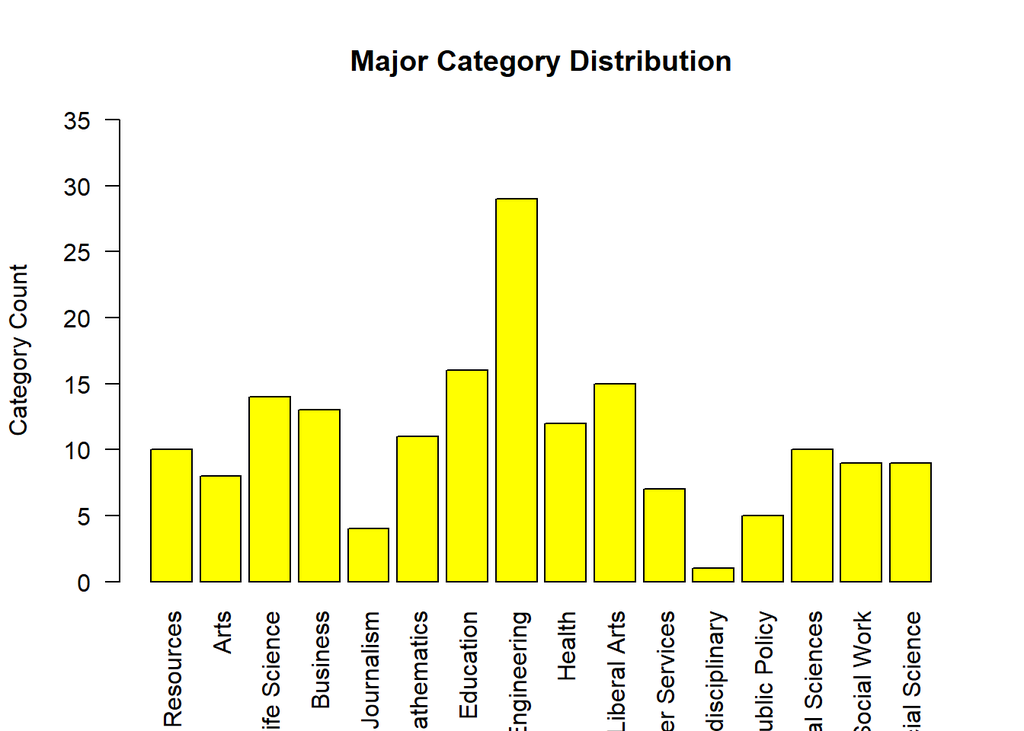

```r
#plot
par(las=2)

barplot(major_count, ylab="Category Count", col = "yellow" , ylim=c(0,35))
title(main="Major Category Distribution", font=12)
```

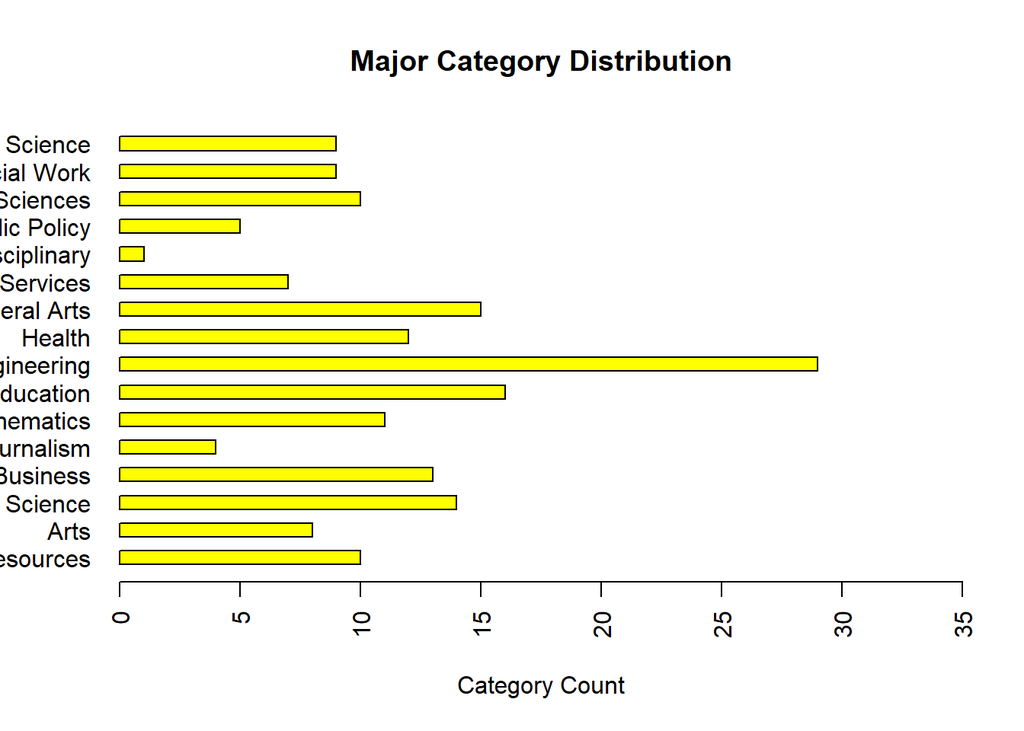

```r
#horizontal plot
barplot(major_count, xlab="Category Count", col = "yellow" , xlim=c(0,35), horiz = TRUE, space = 1, width = 2)
title(main="Major Category Distribution", font=12)
```

```r
# Export data
write.table(df,file="C:\\Users\\Eduardo Cantu\\Documents\\Masters\\Doing_Data_Science\\Homework\\SMU_MSDS_HW\\Week04\\collegeRecent.csv",row.names=FALSE, sep=",")
```

GitHub Link to for this Homework:  
https://github.com/ecantu75/SMU_MSDS_HW.git